# Feature Optimization for Coffee Adulteration Detection Using Hyperspectral Imaging and Artificial Neural Networks: RFE and GA with SNV+SG+2nd Derivative Spectra

Author

Derick Malavi

## Introduction

This project leverages Artificial Neural Networks (ANN) to evaluate their effectiveness in distinguishing authentic coffee from adulterated samples using spectral data. By incorporating feature selection techniques such as Recursive Feature Elimination (RFE) and Genetic Algorithms (GA), the study aims to identify the most relevant spectral features, reducing dimensionality while maintaining model accuracy. ANN’s ability to model complex, non-linear relationships makes it ideal for analyzing high-dimensional spectroscopic datasets. The study evaluates the model’s performance in classifying pure and adulterated coffee across varying adulteration levels.

```r
# Load libraries
warning = FALSE
  suppressWarnings(suppressMessages({
  library(caret)
  library(GA)
  library(ggplot2)
  library(dplyr)
  library(readxl)
  library(readr)
  library(pls)
  library(janitor)
  library(class)
  library(MLmetrics)
  library(MLeval)
  library(themis)
  library(NeuralNetTools)
  library(ROSE)
  library(parallel)
  library(doParallel)
  library(foreach)
  library(pheatmap)
  library(mdatools)
  library(nnet)
  library(ggthemes)
  library(DMwR)
  library(e1071)
  library(knitr)
  library(pROC)
  library(gridExtra)
  library(FactoMineR)
  library(doSNOW)
  library(MASS)
  library(factoextra)
  library(kernlab)}))
```

## Prepare Data

```r
# Load data: snv_sg_2d spectra

hsi_snv_sg_2d <- read.csv("coffee_instant_snv_sg_2d.csv")

# Ensure we have the same number of dimensions and the range of our columns/covariates
dim(hsi_snv_sg_2d)
```

```
[1] 1476  229
```

```r
# Check a few column names
col_check <- colnames(hsi_snv_sg_2d[,c(1:6)])
col_check
```

```
[1] "sample_name"  "binary_class" "three_class"  "cal_val"      "perc_adulter"
[6] "X935.609985"
```

```r
# The spectral values start from column # 6-------> 229

# Convert the class to a factor
hsi_snv_sg_2d$binary_class <- as.factor(hsi_snv_sg_2d$binary_class)
```

## Get the X and y variables

```r
X <- hsi_snv_sg_2d[,c(6:229)]
y <- hsi_snv_sg_2d[,2]

class(y) #Ensure y (target variable) is a factor for classification
```

```
[1] "factor"
```

## Visualize X

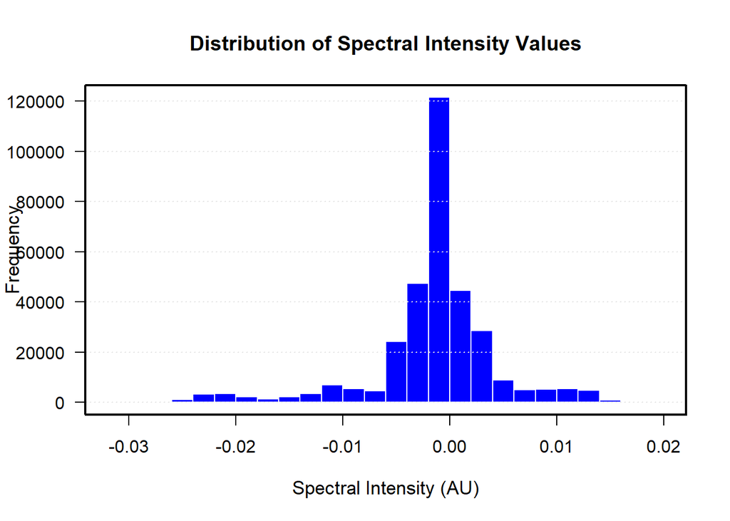

```r
hist(as.matrix(X),
     col = "blue",
     border = "white",
     main = "Distribution of Spectral Intensity Values",
     xlab = "Spectral Intensity (AU)",
     ylab = "Frequency",
     las = 1,
     cex.main = 1.2,
     cex.lab = 1.1,
     breaks = 30)

# Add grid lines
grid(nx = NA, ny = NULL, col = "gray90", lty = "dotted")

# Add box around plot
box(lwd = 2)
```